# S6 RQ2: original vs attritioned

## Description

In this (non-preregistered) analysis, we look at four variables collected at years 12 & 16 which have low levels of missingness, and test the effect of selecting only those who took part at year 21 and 26 time points (“attritioning”).

In scripts seven and eight, we compare the effect of attrition when using IP weighting and imputation.

Suggested by Yasmin.

## Load Data

```r
source("0_load_data.R")

df = df %>%
  filter(!(randomfamid %in% exclude_fams_rq1x)) %>%
  filter(!(randomfamid %in% exclude_fams_onesib)) %>%
  filter(!(randomfamid %in% exclude_fams_rq6y))

## range of participation outcomes to use for attiritioning

range_participation_outcomes = 6:9

variable_comparisons = readRDS(file.path("results","6_variable_comparisons.Rds"))
```

### Focal Variables and timepoints

Attrition time points

```r
cbind(
  rq6y,
  rq6y_labels
) %>%
  knitr::kable(caption = "Outcome Variables")
```

Outcome Variables

| rq6y | rq6y_labels |
| --- | --- |
| lcmfqt1 | Y12: Depression (MFQ) |
| lsdqext1 | Y12: Externalising (SDQ) |
| lcg1 | Y12: Cognitive ability |
| pcexgcsecoregrdm1 | Y16: GCSE grade |

```r
cbind(
  rq1y_twin1[range_participation_outcomes],
  rq1y_twin_labels_clean[range_participation_outcomes]
) %>%
  knitr::kable(caption = "Attrittion time points")
```

Attrittion time points

| u1cdata1 | Y21 (TEDS21 phase-1 questionnaire) |
| --- | --- |
| zmhdata1 | Y26 (TEDS26 questionnaire) |
| zcdata1 | Y26 (CATSLife web tests) |
| hasgeno1 | Genotyped |

## Data Processing

### Transform Raw Results to Dataframe

```r
# Load raw bootstrap results (already loaded above as variable_comparisons)
# variable_comparisons = readRDS(file.path("results", "6_variable_comparisons.Rds"))

# Extract bootstrap_summary from each element
variable_comparisons_df = lapply(variable_comparisons, function(x) x$bootstrap_summary)

# Transform each dataset's results
for(i in seq_along(variable_comparisons_df)){
  for (j in 1:3){ # Keep only md, smd, var, cor_resid (h removed from RQ6)
    variable_comparisons_df[[i]] = variable_comparisons_df[[i]][1:3]
    variable_comparisons_df[[i]][[j]] = do.call(rbind, variable_comparisons_df[[i]][[j]])
    variable_comparisons_df[[i]][[j]]$dataset  = rq1y_twin_labels_clean_extrashort[range_participation_outcomes[i]]
    variable_comparisons_df[[i]][[j]]$stat = c("md","smd","var")[j]
    variable_comparisons_df[[i]][[j]]$variable = rq6y_labels
    rownames(variable_comparisons_df[[i]][[j]]) = NULL
  }
  variable_comparisons_df[[i]] = do.call(rbind.data.frame, variable_comparisons_df[[i]])
}

# Combine all datasets into single dataframe
variable_comparisons_df0 = do.call(rbind.data.frame, variable_comparisons_df)
rownames(variable_comparisons_df0) = NULL

# Save for future use
# saveRDS(variable_comparisons_df0, file.path("results", "6_variable_comparisons_df.Rds"))
```

### Create Table

```r
# Get original variances for rescaling
# original_variances = sapply(rq6y, function(x) stats::var(df[[x]], na.rm = TRUE))

# variable_comparisons_df0 created above in "Transform Raw Results to Dataframe" section
# Optionally can load from disk:
# variable_comparisons_df0 = readRDS(file.path("results", "6_variable_comparisons_df.Rds"))

# Process the dataframe
variable_comparisons_df = variable_comparisons_df0 %>%
  mutate(
    # dataset = rq1y_twin_labels_clean[match(.$dataset, rq1y_twin1)],
    variable = rq6y_labels[match(.$variable, rq6y_labels)]
  ) %>%
  # Rescale variance values
  pivot_longer(cols = starts_with("y")) %>%
  # mutate(
  #   var_constant = original_variances[match(.$variable, rq6y_labels)],
  #   value = case_when(
  #     stat == "var" ~ value / var_constant,
  #     TRUE ~ value
  #   )
  # ) %>%
  # select(-var_constant) %>%
  pivot_wider(
    values_from = value,
    names_from  = name
  ) %>%
  group_by(dataset, stat) %>%
  mutate(
    pval_adj = stats::p.adjust(pval, method = "holm")
  )
```

## Means, SMDs, Variances

### Adolescent Outcomes: Means, SMDs, and Variances

For each adolescent outcome, the table below compares the original (full) sample to the attritioned sample created by setting the outcome to missing for participants who did not take part in a given wave, analogous to the toddlerhood comparison. Row groups correspond to each attrition timepoint. Reported for each outcome are the raw mean difference, standardized mean difference (SMD), and percentage change in variance (attritioned relative to original), each with bootstrap 95% CIs and Bonferroni-Holm adjusted p-values; significant increases are shaded green and decreases red.

```r
variable_comparisons_df %>%
  filter(stat %in% c("md", "smd", "var")) %>%
  select(-starts_with("."),-pd) %>%
  pivot_wider(
    names_from = "stat",
    values_from = c("y","ymin","ymax","pval","pval_adj"),
    id_cols = c("variable", "dataset")
  ) %>%
  dplyr::rename(Outcome = "variable") %>%
  gt(groupname_col = "dataset") %>%
  tab_options(
    table.width = px(800)
  ) %>%

  # Create column spanners (nested headers)
  tab_spanner(
    label = "Mean Difference",
    columns = c(y_md, ymin_md, ymax_md, pval_md, pval_adj_md)
  ) %>%
  tab_spanner(
    label = "Standardized Mean Difference",
    columns = c(y_smd, ymin_smd, ymax_smd, pval_smd, pval_adj_smd)
  ) %>%
  tab_spanner(
    label = "Variance % Change",
    columns = c(y_var, ymin_var, ymax_var, pval_var, pval_adj_var)
  ) %>%

  # Rename columns under each spanner
  cols_label(
    y_md = "Est", ymin_md = "LB", ymax_md = "UB", pval_md = md("p<sub>unadj</sub>"), pval_adj_md = md("p<sub>adj</sub>"),
    y_smd = "Est", ymin_smd = "LB", ymax_smd = "UB", pval_smd = md("p<sub>unadj</sub>"), pval_adj_smd = md("p<sub>adj</sub>"),
    y_var = "Est", ymin_var = "LB", ymax_var = "UB", pval_var = md("p<sub>unadj</sub>"), pval_adj_var = md("p<sub>adj</sub>")
  ) %>%

  # Format numbers
  fmt(
    columns = !contains("var") & !contains("Outcome"),
    fns = function(x) {gbtoolbox::apa_num(x, n_decimal_places = 3)}
  ) %>%
  fmt(
    columns = c("pval_var", "pval_adj_var"),
    fns = function(x) {gbtoolbox::apa_num(x, n_decimal_places = 3)}
  ) %>%
  fmt_percent(
    columns = c("y_var", "ymin_var","ymax_var"),
    decimals = 2,
    drop_trailing_zeros = FALSE,
    drop_trailing_dec_mark = FALSE
  ) %>%
  # Styling - uniform font size
  tab_style(
    style = cell_text(size = px(10)),
    locations = cells_column_spanners()
  ) %>%
  tab_style(
    style = cell_text(size = px(10)),
    locations = cells_body()
  ) %>%
  tab_style(
    style = cell_text(size = px(10), align = "center"),
    locations = cells_row_groups()
  ) %>%
  tab_style(
    style = cell_text(size = px(10)),
    locations = cells_column_labels()
  ) %>%
  tab_style(
    style = cell_text(size = px(10)),
    locations = cells_footnotes()
  ) %>%

  # Highlight significant results - positive effects (light green)
  tab_style(
    style = cell_fill(color = "#d5e8d4"),
    locations = cells_body(
      columns = c(y_md, ymin_md, ymax_md, pval_md, pval_adj_md),
      rows = pval_adj_md < 0.05 & y_md > 0
    )
  ) %>%
  tab_style(
    style = cell_fill(color = "#d5e8d4"),
    locations = cells_body(
      columns = c(y_smd, ymin_smd, ymax_smd, pval_smd, pval_adj_smd),
      rows = pval_adj_smd < 0.05 & y_smd > 0
    )
  ) %>%
  tab_style(
    style = cell_fill(color = "#d5e8d4"),
    locations = cells_body(
      columns = c(y_var, ymin_var, ymax_var, pval_var, pval_adj_var),
      rows = pval_adj_var < 0.05 & y_var > 0
    )
  ) %>%

  # Highlight significant results - negative effects (light red)
  tab_style(
    style = cell_fill(color = "#f8cecc"),
    locations = cells_body(
      columns = c(y_md, ymin_md, ymax_md, pval_md, pval_adj_md),
      rows = pval_adj_md < 0.05 & y_md < 0
    )
  ) %>%
  tab_style(
    style = cell_fill(color = "#f8cecc"),
    locations = cells_body(
      columns = c(y_smd, ymin_smd, ymax_smd, pval_smd, pval_adj_smd),
      rows = pval_adj_smd < 0.05 & y_smd < 0
    )
  ) %>%
  tab_style(
    style = cell_fill(color = "#f8cecc"),
    locations = cells_body(
      columns = c(y_var, ymin_var, ymax_var, pval_var, pval_adj_var),
      rows = pval_adj_var < 0.05 & y_var < 0
    )
  ) %>%

  # Add footnotes
  tab_footnote(
    footnote = md("<em>Note.</em> Est = Estimate, LB = Lower Bound 95% Confidence Interval, UB = Upper Bound 95% Confidence Interval. Significant (p<sub>Bonferroni-Holm</sub>) effects are highlighted in green (increases) or red (decreases)."),
    placement = "right"
  ) %>%
  tab_footnote(
    footnote = "P values are Bonferroni-Holm adjusted within each participation group",
    locations = cells_column_labels(columns = contains("pval_adj")),
    placement = "right"
  ) %>%
  tab_footnote(
    footnote = md("Standardized mean difference = (Mean<sub>original</sub> - Mean<sub>attritioned</sub>) / SD<sub>original</sub>"),
    locations = cells_column_spanners(spanners = "Standardized Mean Difference"),
    placement = "right"
  ) %>%
  tab_footnote(
    footnote = md("Percentage change = (Var<sub>attritioned</sub> - Var<sub>original</sub>) / Var<sub>original</sub>"),
    locations = cells_column_spanners(spanners = "Variance % Change"),
    placement = "right"
  ) %>%
  opt_footnote_marks(marks = c("*", "†","‡"))
```

| Outcome | Mean Difference Est | Mean Difference LB | Mean Difference UB | Mean Difference p<sub>unadj</sub> | Mean Difference p<sub>adj</sub>‡ | Standardized Mean Difference* Est | Standardized Mean Difference* LB | Standardized Mean Difference* UB | Standardized Mean Difference* p<sub>unadj</sub> | Standardized Mean Difference* p<sub>adj</sub>‡ | Variance % Change† Est | Variance % Change† LB | Variance % Change† UB | Variance % Change† p<sub>unadj</sub> | Variance % Change† p<sub>adj</sub>‡ |
| --- | --- | --- | --- | --- | --- | --- | --- | --- | --- | --- | --- | --- | --- | --- | --- |
| Y21 |  |  |  |  |  |  |  |  |  |  |  |  |  |  |  |
| Y12: Depression (MFQ) | -.036 | -.090 | .018 | .197 | .197 | -.011 | -.027 | .005 | .197 | .197 | 0.16% | −4.05% | 4.33% | .929 | .929 |
| Y12: Externalising (SDQ) | -.376 | -.435 | -.318 | .000 | .000 | -.108 | -.125 | -.092 | .000 | .000 | −8.61% | −11.17% | −6.13% | .000 | .000 |
| Y12: Cognitive ability | .079 | .061 | .096 | .000 | .000 | .079 | .062 | .096 | .000 | .000 | −5.01% | −7.45% | −2.56% | .000 | .000 |
| Y16: GCSE grade | .217 | .196 | .238 | .000 | .000 | .177 | .160 | .193 | .000 | .000 | −8.85% | −11.41% | −6.28% | .000 | .000 |
| Y26 (q'aire) |  |  |  |  |  |  |  |  |  |  |  |  |  |  |  |
| Y12: Depression (MFQ) | -.016 | -.079 | .046 | .605 | .605 | -.005 | -.024 | .014 | .605 | .605 | 0.71% | −4.13% | 5.52% | .770 | .770 |
| Y12: Externalising (SDQ) | -.417 | -.484 | -.352 | .000 | .000 | -.120 | -.139 | -.102 | .000 | .000 | −8.28% | −11.19% | −5.43% | .000 | .000 |
| Y12: Cognitive ability | .090 | .069 | .111 | .000 | .000 | .090 | .070 | .111 | .000 | .000 | −5.56% | −8.43% | −2.76% | .000 | .000 |
| Y16: GCSE grade | .220 | .196 | .243 | .000 | .000 | .179 | .160 | .198 | .000 | .000 | −11.88% | −14.60% | −9.16% | .000 | .000 |
| Y26 (web test) |  |  |  |  |  |  |  |  |  |  |  |  |  |  |  |
| Y12: Depression (MFQ) | -.143 | -.251 | -.033 | .010 | .010 | -.043 | -.075 | -.010 | .010 | .010 | −9.34% | −17.65% | −0.95% | .030 | .030 |
| Y12: Externalising (SDQ) | -.676 | -.787 | -.564 | .000 | .000 | -.195 | -.226 | -.163 | .000 | .000 | −13.38% | −17.79% | −8.84% | .000 | .000 |
| Y12: Cognitive ability | .174 | .137 | .211 | .000 | .000 | .174 | .137 | .211 | .000 | .000 | −6.36% | −11.09% | −1.41% | .011 | .022 |
| Y16: GCSE grade | .360 | .320 | .401 | .000 | .000 | .293 | .261 | .326 | .000 | .000 | −11.64% | −16.60% | −6.59% | .000 | .000 |
| Genotyped |  |  |  |  |  |  |  |  |  |  |  |  |  |  |  |
| Y12: Depression (MFQ) | -.004 | -.036 | .028 | .799 | .950 | -.001 | -.011 | .008 | .799 | .950 | −1.00% | −3.83% | 1.65% | .484 | .968 |
| Y12: Externalising (SDQ) | -.012 | -.046 | .020 | .462 | .950 | -.004 | -.013 | .006 | .462 | .950 | −0.04% | −1.45% | 1.28% | .978 | .978 |
| Y12: Cognitive ability | .006 | -.006 | .017 | .317 | .950 | .006 | -.006 | .017 | .317 | .950 | −2.61% | −4.12% | −1.12% | .001 | .003 |
| Y16: GCSE grade | .022 | .008 | .036 | .002 | .009 | .018 | .006 | .029 | .002 | .009 | −1.52% | −3.18% | 0.11% | .071 | .214 |

### Create Circular Heatmaps

#### Standardised Mean Differences

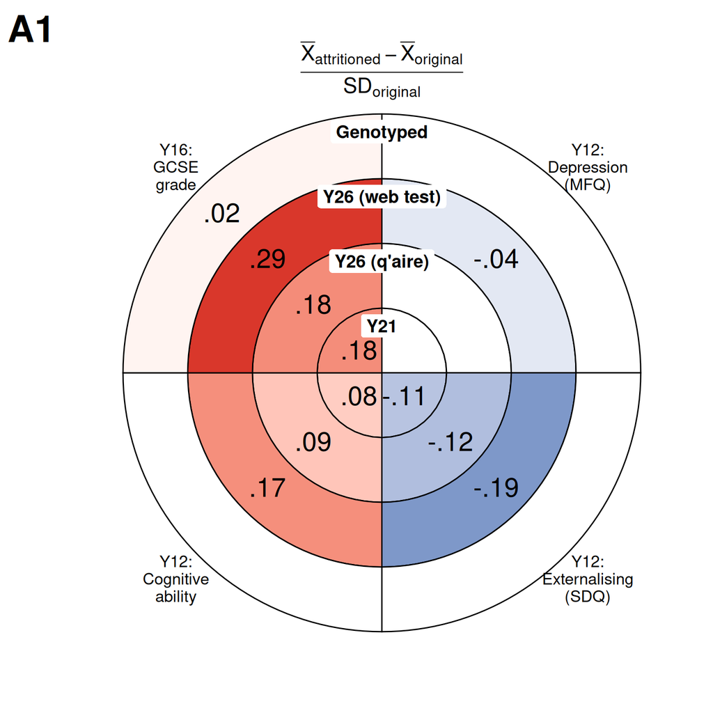

```r
# Create circular heatmap for SMD
heatmap_data_smd = variable_comparisons_df %>%
  filter(stat == "smd") %>%
  mutate(
    outcome_labeled = rq1y_twin_labels_clean_extrashort[match(dataset, rq1y_twin_labels_clean_extrashort)],
    outcome_labeled = factor(outcome_labeled, levels = rq1y_twin_labels_clean_extrashort[range_participation_outcomes]),
    Variables_wrapped = str_wrap(variable, width = 8),
    # Set fill value to NA if not significant, otherwise keep original sign
    fill_value = case_when(
      pval_adj < 0.05 ~ y,
      TRUE ~ NA
    )
  ) %>%
  # Use fixed order from rq6y_labels
  mutate(
    variable = factor(variable, levels = rq6y_labels),
    Variables_wrapped = factor(Variables_wrapped, levels = str_wrap(rq6y_labels, width = 8))
  )

ggplot(heatmap_data_smd, aes(x = Variables_wrapped, y = outcome_labeled)) +
  geom_tile(aes(fill = fill_value),
            color = "black",
            size = 0.5) +
  geom_text(
    aes(label = ifelse(pval_adj < 0.05,
                       gsub("^(-?)0\\.", "\\1.", sprintf("%.2f", y)), ""),
        size = 7.5
    ),
    color = "black"
  ) +
  scale_size_identity() +
  coord_polar(theta = "x", start = 0, direction = 1, clip = "off") +
  scale_fill_gradient2(
    low = "#2166ac",
    mid = "white",
    high = "#d73027",
    midpoint = 0,
    limits = c(-0.3, 0.3),
    na.value = "white",
    guide = "none"
  ) +
  labs(
    subtitle = expression(frac(bar(X)[attritioned] - bar(X)[original], SD[original])),
    tag = "A1"
  ) +
  theme_minimal() +
  theme(
    axis.text.x = element_text(angle = 0, size = 13, color = "black"),
    axis.text.y = element_blank(),
    axis.title = element_blank(),
    panel.grid = element_blank(),
    panel.background = element_blank(),
    plot.background = element_blank(),
    plot.title = element_blank(),
    plot.subtitle = element_text(hjust = 0.5, size = 17, margin = margin(b = -45)),
    plot.tag = element_text(hjust = 0, vjust = 0, size = 30, face = "bold"),
    plot.tag.position = "topleft"
  ) +
  {
    y_positions = seq_along(levels(heatmap_data_smd$outcome_labeled))
    labels = levels(heatmap_data_smd$outcome_labeled)

    lapply(seq_along(labels), function(i) {
      annotate("label", x = 0.5, y = y_positions[i],
               label = labels[i], size = 5, hjust = 0.5, angle = 0, vjust = -0.12, fontface = "bold",
               fill = "white", label.size = 0)
    })
  }
```

```r
save_plot("6_rq6_circular_heatmap_smd", width = 8, height = 8, trim = TRUE)
```

📊 View Full Resolution SMD Heatmap (PNG)

#### Variance Differences

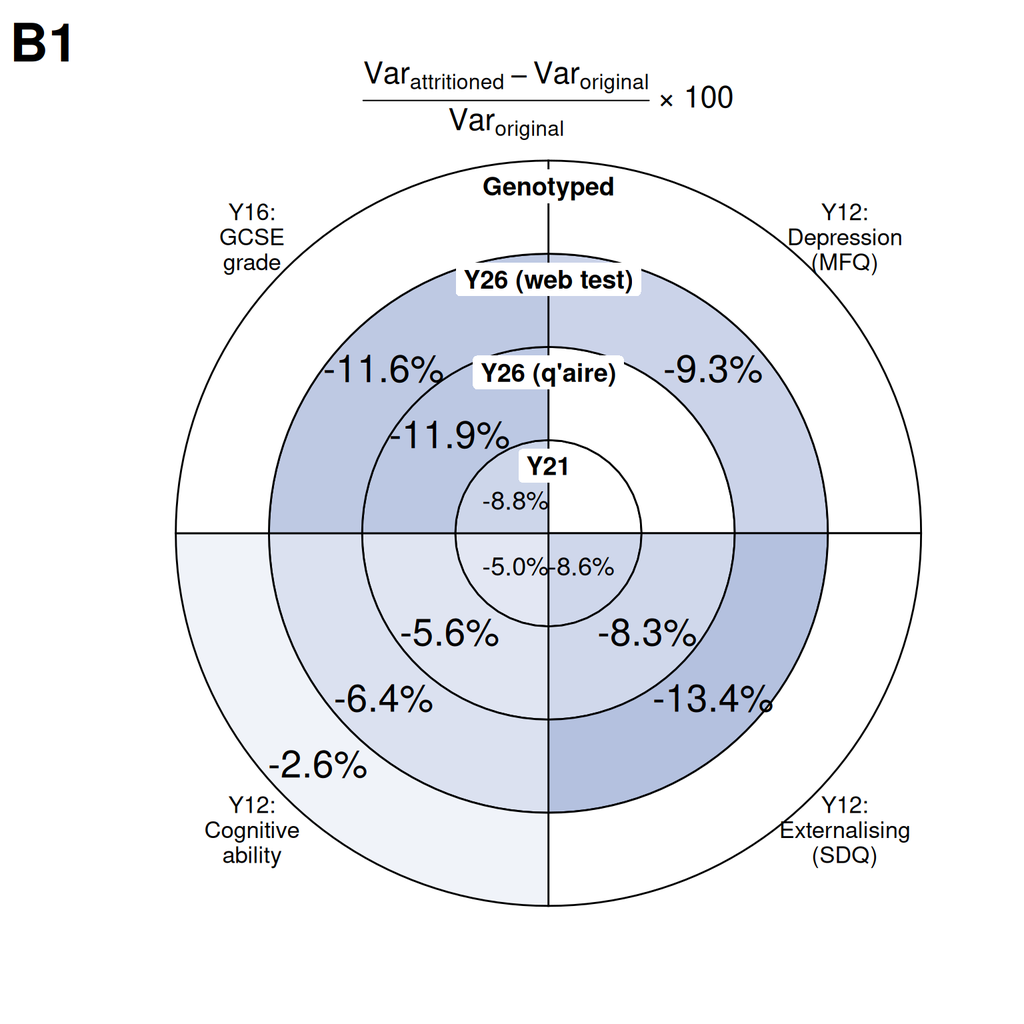

```r
# Create circular heatmap for variance differences
heatmap_data_var = variable_comparisons_df %>%
  filter(stat == "var") %>%
  mutate(
    outcome_labeled = rq1y_twin_labels_clean_extrashort[match(dataset, rq1y_twin_labels_clean_extrashort)],
    outcome_labeled = factor(outcome_labeled, levels = rq1y_twin_labels_clean_extrashort[range_participation_outcomes]),
    Variables_wrapped = str_wrap(variable, width = 8),
    # Set fill value to NA if not significant, otherwise keep original sign
    fill_value = case_when(
      pval_adj < 0.05 ~ y,
      TRUE ~ NA
    )
  ) %>%
  # Use fixed order from rq6y_labels
  mutate(
    variable = factor(variable, levels = rq6y_labels),
    Variables_wrapped = factor(Variables_wrapped, levels = str_wrap(rq6y_labels, width = 8))
  )

ggplot(heatmap_data_var, aes(x = Variables_wrapped, y = outcome_labeled)) +
  geom_tile(aes(fill = fill_value),
            color = "black",
            size = 0.5) +
  geom_text(
    aes(label = ifelse(pval_adj < 0.05,
                       paste0(sprintf("%.1f", y * 100), "%"), ""),
        size = ifelse(dataset == "Y21", 5, 7.5)
    ),
    color = "black"
  ) +
  scale_size_identity() +
  coord_polar(theta = "x", start = 0, direction = 1, clip = "off") +
  scale_fill_gradient2(
    low = "#2166ac",
    mid = "white",
    high = "#d73027",
    midpoint = 0,
    limits = c(-.35, .35),
    na.value = "white",
    guide = "none"
  ) +
  labs(
    subtitle = expression(frac(Var[attritioned] - Var[original], Var[original]) ~ "\u00D7" ~ 100),
    tag = "B1"
  ) +
  theme_minimal() +
  theme(
    axis.text.x = element_text(angle = 0, size = 13, color = "black"),
    axis.text.y = element_blank(),
    axis.title = element_blank(),
    panel.grid = element_blank(),
    panel.background = element_blank(),
    plot.background = element_blank(),
    plot.title = element_blank(),
    plot.subtitle = element_text(hjust = 0.5, size = 17, margin = margin(b = -45)),
    plot.tag = element_text(hjust = 0, vjust = 0, size = 30, face = "bold"),
    plot.tag.position = "topleft"
  ) +
  {
    y_positions = seq_along(levels(heatmap_data_var$outcome_labeled))
    labels = levels(heatmap_data_var$outcome_labeled)

    lapply(seq_along(labels), function(i) {
      annotate("label", x = 0.5, y = y_positions[i],
               label = labels[i], size = 5, hjust = 0.5, angle = 0, vjust = -0.12, fontface = "bold",
               fill = "white", label.size = 0)
    })
  }
```

```r
save_plot("6_rq6_circular_heatmap_var", width = 8, height = 8, trim = TRUE)
```

📊 View Full Resolution Variance Heatmap (PNG)

## Correlations

First, some code to establish how to convert variable labels from matrix to dataframe formats.

```r
test_correlation_matrix = matrix(
  nrow = length(rq6y),
  ncol = length(rq6y)
  )

for(i in seq_along(rq6y)){
  for(j in seq_along(rq6y)){
    test_correlation_matrix[i,j] = paste(rq6y[i], rq6y[j], collapse = " ")
  }
}

x = test_correlation_matrix[lower.tri(test_correlation_matrix)]

x_var = str_extract(x, "^\\S+")
y_var = str_extract(x, "\\S+$")

rm(test_correlation_matrix,x)
```

### Plot differences in correlations

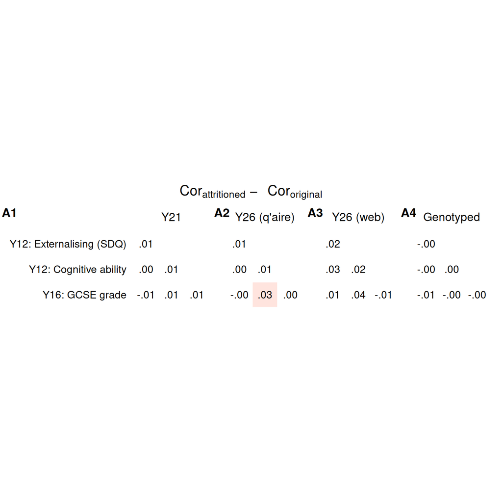

```r
correlation_comparisons = lapply(variable_comparisons, function(x) x$bootstrap_summary$cor_resid)

correlation_comparisons = lapply(correlation_comparisons, function(x) do.call(rbind.data.frame, x))

correlation_comparisons = lapply(correlation_comparisons, function(x) {
  x %>%
    mutate(
      pval_adj = stats::p.adjust(pval, method = "holm"),
      x_var = x_var,
      y_var = y_var
    )
})

library(patchwork)

rq1y_twin_labels_clean_extrashort2 = rq1y_twin_labels_clean_extrashort
rq1y_twin_labels_clean_extrashort2[8] = "Y26 (web)"

plots = lapply(1:length(correlation_comparisons), function(i) {
  plot_lower_triangular_matrix2(
    data = correlation_comparisons[[i]],
    variables = rq6y,
    labels = rq6y_labels,
    x_var_col = "x_var",
    y_var_col = "y_var",
    value_col = "y",
    p_col = "pval_adj",
    p_threshold = 0.05,
    show_values = TRUE,
    text_size = 4.2,
    title = rq1y_twin_labels_clean_extrashort2[range_participation_outcomes[i]],
    caption = NULL,
    method = "none"
  ) +
  labs(tag = paste0("A", i)) +
  theme(
    plot.title        = element_text(hjust=0.5),
    axis.text         = element_text(color = "black"),
    plot.background   = element_blank(),
    panel.background  = element_blank(),
    legend.background = element_blank(),
    plot.tag          = element_text(size = 14, face = "bold"),
    plot.tag.position = c(0, 1),
    axis.text.y       = if (i > 1) element_blank() else element_text(size = 12),
    axis.text.x       = element_blank()
  )
})

patchwork::wrap_plots(
  plots,
  ncol = 4) +
  plot_annotation(
    title = expression(Cor[attritioned] ~ - ~ ~ Cor[original]),
    theme = theme(
      plot.title    = element_text(hjust = 0.5, size = 16, face = "bold"),
      plot.subtitle = element_text(hjust = 0.5, size = 13)
      )
  )
```

```r
save_plot(
  "6_rq6_correlations", width = 9, height = NA, trim = TRUE, trim_margin = 0
  )
```

📊 View Full Resolution Plot

### Adolescent Outcomes: Correlations

The table below shows, for each pair of adolescent outcomes, the difference between the correlation in the attritioned sample and the correlation in the original sample (row groups = attrition timepoint), with bootstrap 95% CIs and unadjusted/Bonferroni-Holm adjusted p-values; significant increases are shaded green and decreases red.

```r
cor_table = bind_rows(correlation_comparisons, .id = "timepoint") %>%
  mutate(
    dataset = rq1y_twin_labels_clean_extrashort[match(timepoint, rq1y_twin1)],
    x_var_label = rq6y_labels[match(x_var, rq6y)],
    y_var_label = rq6y_labels[match(y_var, rq6y)],
    pair = paste(x_var_label, "×", y_var_label)
  ) %>%
  select(dataset, pair, y, ymin, ymax, pval, pval_adj) %>%
  gt(groupname_col = "dataset") %>%
  tab_options(
    table.width = px(800)
  ) %>%

  # Rename columns
  cols_label(
    pair = "Variable Pair",
    y = "Est",
    ymin = "LB",
    ymax = "UB",
    pval = md("p<sub>unadj</sub>"),
    pval_adj = md("p<sub>adj</sub>")
  ) %>%

  # Create column spanner
  tab_spanner(
    label = "Correlation Difference",
    columns = c(y, ymin, ymax, pval, pval_adj)
  ) %>%

  # Format numbers
  fmt(
    columns = c(y, ymin, ymax),
    fns = function(x) {gbtoolbox::apa_num(x, n_decimal_places = 3)}
  ) %>%
  fmt(
    columns = c(pval, pval_adj),
    fns = function(x) {gbtoolbox::apa_num(x, n_decimal_places = 3)}
  ) %>%

  # Styling - uniform font size
  tab_style(
    style = cell_text(size = px(10)),
    locations = cells_column_spanners()
  ) %>%
  tab_style(
    style = cell_text(size = px(10)),
    locations = cells_body()
  ) %>%
  tab_style(
    style = cell_text(size = px(10), align = "center"),
    locations = cells_row_groups()
  ) %>%
  tab_style(
    style = cell_text(size = px(10)),
    locations = cells_column_labels()
  ) %>%
  tab_style(
    style = cell_text(size = px(10)),
    locations = cells_footnotes()
  ) %>%

  # Highlight significant results - positive effects (light green)
  tab_style(
    style = cell_fill(color = "#d5e8d4"),
    locations = cells_body(
      columns = c(y, ymin, ymax, pval, pval_adj),
      rows = pval_adj < 0.05 & y > 0
    )
  ) %>%

  # Highlight significant results - negative effects (light red)
  tab_style(
    style = cell_fill(color = "#f8cecc"),
    locations = cells_body(
      columns = c(y, ymin, ymax, pval, pval_adj),
      rows = pval_adj < 0.05 & y < 0
    )
  ) %>%

  # Add footnotes
  tab_footnote(
    footnote = md("<em>Note.</em> Est = Estimate, LB = Lower Bound 95% Confidence Interval, UB = Upper Bound 95% Confidence Interval. Significant (p<sub>Bonferroni-Holm</sub>) effects are highlighted in green (increases) or red (decreases)."),
    placement = "right"
  ) %>%
  tab_footnote(
    footnote = "P values are Bonferroni-Holm adjusted within each attrition timepoint",
    locations = cells_column_labels(columns = pval_adj),
    placement = "right"
  ) %>%
  tab_footnote(
    footnote = md("Correlation difference = Cor<sub>attritioned</sub> - Cor<sub>original</sub>"),
    locations = cells_column_spanners(spanners = "Correlation Difference"),
    placement = "right"
  ) %>%
  opt_footnote_marks(marks = c("*", "†", "‡"))

cor_table
```

| Variable Pair | Correlation Difference* Est | Correlation Difference* LB | Correlation Difference* UB | Correlation Difference* p<sub>unadj</sub> | Correlation Difference* p<sub>adj</sub>† |
| --- | --- | --- | --- | --- | --- |
| Y21 |  |  |  |  |  |
| Y12: Externalising (SDQ) × Y12: Depression (MFQ) | .013 | -.001 | .028 | .071 | .424 |
| Y12: Cognitive ability × Y12: Depression (MFQ) | .001 | -.016 | .018 | .928 | .928 |
| Y16: GCSE grade × Y12: Depression (MFQ) | -.010 | -.027 | .007 | .241 | .824 |
| Y12: Cognitive ability × Y12: Externalising (SDQ) | .011 | -.006 | .029 | .206 | .824 |
| Y16: GCSE grade × Y12: Externalising (SDQ) | .013 | -.004 | .030 | .148 | .742 |
| Y16: GCSE grade × Y12: Cognitive ability | .007 | -.007 | .021 | .292 | .824 |
| Y26 (q'aire) |  |  |  |  |  |
| Y12: Externalising (SDQ) × Y12: Depression (MFQ) | .009 | -.009 | .026 | .315 | 1.000 |
| Y12: Cognitive ability × Y12: Depression (MFQ) | .004 | -.017 | .025 | .736 | 1.000 |
| Y16: GCSE grade × Y12: Depression (MFQ) | -.000 | -.021 | .021 | .995 | 1.000 |
| Y12: Cognitive ability × Y12: Externalising (SDQ) | .013 | -.008 | .035 | .215 | 1.000 |
| Y16: GCSE grade × Y12: Externalising (SDQ) | .031 | .011 | .052 | .003 | .018 |
| Y16: GCSE grade × Y12: Cognitive ability | .004 | -.012 | .021 | .618 | 1.000 |
| Y26 (web test) |  |  |  |  |  |
| Y12: Externalising (SDQ) × Y12: Depression (MFQ) | .025 | -.005 | .054 | .109 | .547 |
| Y12: Cognitive ability × Y12: Depression (MFQ) | .026 | -.011 | .063 | .174 | .695 |
| Y16: GCSE grade × Y12: Depression (MFQ) | .013 | -.024 | .051 | .492 | .984 |
| Y12: Cognitive ability × Y12: Externalising (SDQ) | .018 | -.018 | .055 | .319 | .957 |
| Y16: GCSE grade × Y12: Externalising (SDQ) | .040 | .005 | .075 | .025 | .149 |
| Y16: GCSE grade × Y12: Cognitive ability | -.005 | -.035 | .023 | .742 | .984 |
| Genotyped |  |  |  |  |  |
| Y12: Externalising (SDQ) × Y12: Depression (MFQ) | -.001 | -.009 | .007 | .845 | 1.000 |
| Y12: Cognitive ability × Y12: Depression (MFQ) | -.000 | -.011 | .011 | .988 | 1.000 |
| Y16: GCSE grade × Y12: Depression (MFQ) | -.008 | -.019 | .002 | .130 | .781 |
| Y12: Cognitive ability × Y12: Externalising (SDQ) | .000 | -.010 | .011 | .955 | 1.000 |
| Y16: GCSE grade × Y12: Externalising (SDQ) | -.000 | -.009 | .009 | .983 | 1.000 |
| Y16: GCSE grade × Y12: Cognitive ability | -.003 | -.011 | .006 | .532 | 1.000 |

*Note.* Est = Estimate, LB = Lower Bound 95% Confidence Interval, UB = Upper Bound 95% Confidence Interval. Significant (p<sub>Bonferroni-Holm</sub>) effects are highlighted in green (increases) or red (decreases).  
* Correlation difference = Cor<sub>attritioned</sub> - Cor<sub>original</sub>  
† P values are Bonferroni-Holm adjusted within each attrition timepoint

### Percentiles of effects

```r
bind_rows(correlation_comparisons, .id = "timepoint") %>%
  mutate(
    x_var_label = rq6y_labels[match(x_var, rq6y)],
    y_var_label = rq6y_labels[match(y_var, rq6y)],
    pair = paste(x_var_label, "×", y_var_label)
  ) %>%
  select(pair, y, pval_adj) %>%
  summarise(
    n_pairs = dplyr::n(),
    mean    = mean(abs(y)),
    p50     = quantile(abs(y), .50),
    p90     = quantile(abs(y), .90),
    p95     = quantile(abs(y), .95),
    max     = max(abs(y))
  ) %>%
  gt() %>%
  cols_label(
    n_pairs = "Pairs (total)",
    mean    = "Mean",
    p50     = "Median",
    p90     = "90th",
    p95     = "95th",
    max     = "Max"
  ) %>%
  fmt_number(columns = c(mean, p50, p90, p95, max), decimals = 3) %>%
  tab_spanner(
    label = md("|Correlation Change| Percentiles"),
    columns = c(p50, p90, p95, max)
  ) %>%
  tab_style(
    style = cell_text(size = px(11)),
    locations = list(cells_body(), cells_column_labels(), cells_column_spanners())
  ) %>%
  tab_footnote(
    footnote = md("<em>Note.</em> Percentiles of |r<sub>attritioned</sub> − r<sub>original</sub>| across all variable pairs and timepoints."),
    placement = "right"
  )
```

| Pairs (total) | Mean | \|Correlation Change\| Percentiles Median | \|Correlation Change\| Percentiles 90th | \|Correlation Change\| Percentiles 95th | \|Correlation Change\| Percentiles Max |
| --- | --- | --- | --- | --- | --- |
| 24 | 0.011 | 0.009 | 0.026 | 0.030 | 0.040 |

*Note.* Percentiles of |r<sub>attritioned</sub> − r<sub>original</sub>| across all variable pairs and timepoints.

### Plot of original correlations

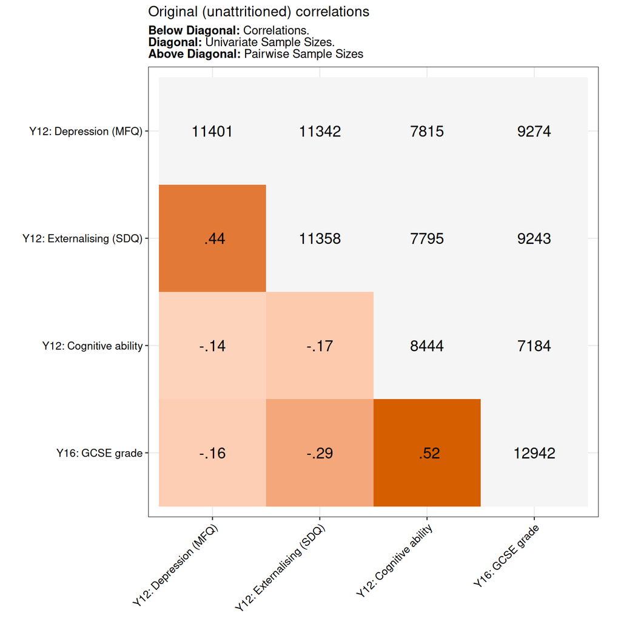

```r
df %>%
  select(all_of(rq6y)) %>%
  `colnames<-`(rq6y_labels) %>%
  as.data.frame() %>%
  gbtoolbox::plot_correlations(
    confidence_interval = FALSE,
    text_size_r = 5
  ) +
  labs(
    title = "Original (unattritioned) correlations",
    subtitle = "**Below Diagonal:** Correlations.<br>**Diagonal:** Univariate Sample Sizes.<br>**Above Diagonal:** Pairwise Sample Sizes") +
  theme(
    axis.text = element_text(color = "black", size = 10),
    plot.subtitle = ggtext::element_markdown()
  )
```

```r
save_plot("6_rq6_original_correlations", height = 5.2, width = 5.2)
```

View Plot

## ACE Comparison

```r
# Extract ACE estimates and differences from all datasets
ace_estimates_list = lapply(variable_comparisons, function(x) x$ace_est_summary)
ace_differences_list = lapply(variable_comparisons, function(x) x$ace_diff_summary)

# Add dataset identifier to each
for(i in seq_along(ace_estimates_list)){
  ace_estimates_list[[i]]$dataset = rq1y_twin1[range_participation_outcomes[i]]
  ace_differences_list[[i]]$dataset = rq1y_twin1[range_participation_outcomes[i]]
}

# Combine into single dataframes
ace_estimates = do.call(rbind, ace_estimates_list)
ace_differences = do.call(rbind, ace_differences_list)

# Add readable dataset labels
ace_estimates$dataset_label = rq1y_twin_labels_clean[match(ace_estimates$dataset, rq1y_twin1)]
ace_differences$dataset_label = rq1y_twin_labels_clean[match(ace_differences$dataset, rq1y_twin1)]
```

### Table - ACE estimates

```r
ace_estimates %>%
  filter(par %in% c("a", "c", "e")) %>%
  select(-starts_with("."), -n, -pd, -pval) %>%
  mutate(
    name_clean = rq6y_labels[match(name, rq6y)],
    group = ifelse(group == "df1", "Attritioned", "Original")
  ) %>%
  pivot_wider(
    id_cols = c(dataset_label, name_clean, par, sex),
    names_from = group,
    values_from = c(y, ymin, ymax),
    names_sep = "_"
  ) %>%
  select(dataset_label, name_clean, par, sex,
         y_Original, ymin_Original, ymax_Original,
         y_Attritioned, ymin_Attritioned, ymax_Attritioned) %>%
  arrange(sex, dataset_label, name_clean, par) %>%
  mutate(par = toupper(par)) %>%
  gt(groupname_col = "sex") %>%
  fmt_number(decimals = 3) %>%
  tab_row_group(
    label = "Male",
    rows = sex == "male"
  ) %>%
  tab_row_group(
    label = "Female",
    rows = sex == "female"
  ) %>%
  cols_hide(sex) %>%
  cols_label(
    dataset_label = "Dataset",
    name_clean = "Variable",
    par = "",
    y_Original = "Est",
    ymin_Original = "Lower",
    ymax_Original = "Upper",
    y_Attritioned = "Est",
    ymin_Attritioned = "Lower",
    ymax_Attritioned = "Upper"
  ) %>%
  tab_spanner(
    label = "Original",
    columns = c(y_Original, ymin_Original, ymax_Original)
  ) %>%
  tab_spanner(
    label = "Attritioned",
    columns = c(y_Attritioned, ymin_Attritioned, ymax_Attritioned)
  ) %>%
  tab_options(
    table.font.size = px(9)
  )
```

| Dataset | Variable |  | Original Est | Original Lower | Original Upper | Attritioned Est | Attritioned Lower | Attritioned Upper |
| --- | --- | --- | --- | --- | --- | --- | --- | --- |
| Female |  |  |  |  |  |  |  |  |
| Genotyped | Y12: Cognitive ability | A | 0.426 | 0.309 | 0.545 | 0.452 | 0.319 | 0.591 |
| Genotyped | Y12: Cognitive ability | C | 0.273 | 0.162 | 0.379 | 0.239 | 0.106 | 0.365 |
| Genotyped | Y12: Cognitive ability | E | 0.301 | 0.271 | 0.333 | 0.309 | 0.277 | 0.342 |
| Genotyped | Y12: Depression (MFQ) | A | 0.219 | 0.001 | 0.433 | 0.234 | 0.000 | 0.449 |
| Genotyped | Y12: Depression (MFQ) | C | 0.206 | 0.024 | 0.379 | 0.182 | 0.000 | 0.378 |
| Genotyped | Y12: Depression (MFQ) | E | 0.575 | 0.504 | 0.643 | 0.584 | 0.511 | 0.653 |
| Genotyped | Y12: Externalising (SDQ) | A | 0.494 | 0.393 | 0.550 | 0.489 | 0.372 | 0.551 |
| Genotyped | Y12: Externalising (SDQ) | C | 0.012 | 0.000 | 0.093 | 0.018 | 0.000 | 0.117 |
| Genotyped | Y12: Externalising (SDQ) | E | 0.494 | 0.449 | 0.542 | 0.494 | 0.447 | 0.544 |
| Genotyped | Y16: GCSE grade | A | 0.544 | 0.463 | 0.628 | 0.572 | 0.477 | 0.672 |
| Genotyped | Y16: GCSE grade | C | 0.347 | 0.265 | 0.425 | 0.317 | 0.220 | 0.410 |
| Genotyped | Y16: GCSE grade | E | 0.109 | 0.096 | 0.122 | 0.110 | 0.097 | 0.125 |
| Y21 (TEDS21 phase-1 questionnaire) | Y12: Cognitive ability | A | 0.426 | 0.310 | 0.544 | 0.465 | 0.323 | 0.612 |
| Y21 (TEDS21 phase-1 questionnaire) | Y12: Cognitive ability | C | 0.273 | 0.163 | 0.380 | 0.222 | 0.087 | 0.350 |
| Y21 (TEDS21 phase-1 questionnaire) | Y12: Cognitive ability | E | 0.301 | 0.272 | 0.332 | 0.313 | 0.277 | 0.353 |
| Y21 (TEDS21 phase-1 questionnaire) | Y12: Depression (MFQ) | A | 0.220 | 0.000 | 0.431 | 0.148 | 0.000 | 0.410 |
| Y21 (TEDS21 phase-1 questionnaire) | Y12: Depression (MFQ) | C | 0.205 | 0.028 | 0.382 | 0.267 | 0.044 | 0.424 |
| Y21 (TEDS21 phase-1 questionnaire) | Y12: Depression (MFQ) | E | 0.574 | 0.505 | 0.642 | 0.585 | 0.501 | 0.662 |
| Y21 (TEDS21 phase-1 questionnaire) | Y12: Externalising (SDQ) | A | 0.493 | 0.391 | 0.549 | 0.508 | 0.398 | 0.570 |
| Y21 (TEDS21 phase-1 questionnaire) | Y12: Externalising (SDQ) | C | 0.013 | 0.000 | 0.094 | 0.011 | 0.000 | 0.101 |
| Y21 (TEDS21 phase-1 questionnaire) | Y12: Externalising (SDQ) | E | 0.494 | 0.450 | 0.540 | 0.481 | 0.429 | 0.536 |
| Y21 (TEDS21 phase-1 questionnaire) | Y16: GCSE grade | A | 0.544 | 0.464 | 0.631 | 0.591 | 0.484 | 0.711 |
| Y21 (TEDS21 phase-1 questionnaire) | Y16: GCSE grade | C | 0.347 | 0.263 | 0.426 | 0.305 | 0.189 | 0.411 |
| Y21 (TEDS21 phase-1 questionnaire) | Y16: GCSE grade | E | 0.108 | 0.096 | 0.122 | 0.103 | 0.089 | 0.119 |
| Y26 (CATSLife web tests) | Y12: Cognitive ability | A | 0.427 | 0.307 | 0.547 | 0.423 | 0.201 | 0.661 |
| Y26 (CATSLife web tests) | Y12: Cognitive ability | C | 0.272 | 0.159 | 0.381 | 0.256 | 0.029 | 0.460 |
| Y26 (CATSLife web tests) | Y12: Cognitive ability | E | 0.301 | 0.271 | 0.333 | 0.320 | 0.268 | 0.377 |
| Y26 (CATSLife web tests) | Y12: Depression (MFQ) | A | 0.220 | 0.000 | 0.434 | 0.216 | 0.000 | 0.536 |
| Y26 (CATSLife web tests) | Y12: Depression (MFQ) | C | 0.205 | 0.024 | 0.378 | 0.192 | 0.000 | 0.426 |

[output cut: 68 more lines]

### Adolescent Outcomes: Attritioned vs. Original ACE Estimates

The table below compares the ACE (Additive genetic, shared environment, non-shared environment) variance component estimates from twin models fitted to the original vs. attritioned adolescent samples, separately by sex and attrition timepoint. For each outcome and component (A, C, E) it shows the original and attritioned estimates, their difference with bootstrap 95% CI, and a Bonferroni-Holm adjusted p-value (adjusted within each dataset group); significant differences are highlighted green. This mirrors the format of the Toddlerhood Outcomes ACE Estimates and Differences table.

```r
ace_differences_tbl = ace_differences  %>%
  group_by(dataset) %>%
  mutate(
    pval_adj = stats::p.adjust(pval, method = "holm")
  ) %>%
  ungroup()

ace_estimates_wide = ace_estimates %>%
  filter(par %in% c("a", "c", "e")) %>%
  mutate(
    name_clean = rq6y_labels[match(name, rq6y)],
    group = ifelse(group == "df1", "Attritioned", "Original")
  ) %>%
  select(dataset_label, name_clean, par, sex, group, y) %>%
  pivot_wider(
    id_cols = c(dataset_label, name_clean, par, sex),
    names_from = group,
    values_from = y,
    names_prefix = "y_"
  )
ace_differences_tbl %>%
  mutate(name_clean = rq6y_labels[match(name, rq6y)]) %>%
  select(dataset_label, name_clean, par, sex, y, ymin, ymax, pval_adj) %>%
  left_join(
    ace_estimates_wide,
    by = c("dataset_label", "name_clean", "par", "sex")
  ) %>%
  select(dataset_label, name_clean, par, y_Original, y_Attritioned, y, ymin, ymax, pval_adj, sex) %>%
  mutate(
    name_clean = factor(name_clean, levels = rq6y_labels)
    ) %>%
  arrange(sex, dataset_label, name_clean, par) %>%
  mutate(par = toupper(par)) %>%
  gt(groupname_col = "sex") %>%
  fmt_number(decimals = 3) %>%
  tab_row_group(
    label = "Male",
    rows = sex == "male"
  ) %>%
  tab_row_group(
    label = "Female",
    rows = sex == "female"
  ) %>%
  cols_hide(sex) %>%
  cols_label(
    dataset_label = "Dataset",
    name_clean = "Variable",
    par = "",
    y_Original = "Original",
    y_Attritioned = "Attritioned",
    y = "Diff",
    ymin = "Lower",
    ymax = "Upper",
    pval_adj = "p"
  ) %>%
  tab_spanner(
    label = "95% CI",
    columns = c(ymin, ymax)
  ) %>%
  tab_spanner(
    label = "Estimates",
    columns = c(y_Attritioned, y_Original)
  ) %>%
  tab_style(
    style = cell_fill(color = "lightgreen"),
    locations = cells_body(
      columns = everything(),
      rows = pval_adj < 0.05
    )
  ) %>%
  tab_footnote(
    footnote = "Difference = Attritioned − Original. P values are Bonferroni-Holm adjusted within each dataset group",
    locations = cells_column_labels(columns = pval_adj)
  ) %>%
  tab_options(
    table.font.size = px(9)
  )
```

| Dataset | Variable |  | Estimates Attritioned | Estimates Original | Diff | 95% CI Lower | 95% CI Upper | p<sup>1</sup> |  |
| --- | --- | --- | --- | --- | --- | --- | --- | --- | --- |
| Female |  |  |  |  |  |  |  |  |  |
| Genotyped | Y12: Depression (MFQ) | A | 0.234 | 0.219 | 0.015 | −0.088 | 0.110 |  | 1.000 |
| Genotyped | Y12: Depression (MFQ) | C | 0.182 | 0.206 | −0.024 | −0.110 | 0.066 | 1.000 |  |
| Genotyped | Y12: Depression (MFQ) | E | 0.584 | 0.575 | 0.009 | −0.017 | 0.043 | 1.000 |  |
| Genotyped | Y12: Externalising (SDQ) | A | 0.489 | 0.494 | −0.005 | −0.064 | 0.034 | 1.000 |  |
| Genotyped | Y12: Externalising (SDQ) | C | 0.018 | 0.012 | 0.005 | −0.031 | 0.059 | 1.000 |  |
| Genotyped | Y12: Externalising (SDQ) | E | 0.494 | 0.494 | 0.000 | −0.015 | 0.014 | 1.000 |  |
| Genotyped | Y12: Cognitive ability | A | 0.452 | 0.426 | 0.026 | −0.038 | 0.090 | 1.000 |  |
| Genotyped | Y12: Cognitive ability | C | 0.239 | 0.273 | −0.033 | −0.098 | 0.030 | 1.000 |  |
| Genotyped | Y12: Cognitive ability | E | 0.309 | 0.301 | 0.008 | −0.001 | 0.016 | 1.000 |  |
| Genotyped | Y16: GCSE grade | A | 0.572 | 0.544 | 0.028 | −0.032 | 0.085 | 1.000 |  |
| Genotyped | Y16: GCSE grade | C | 0.317 | 0.347 | −0.030 | −0.085 | 0.029 | 1.000 |  |
| Genotyped | Y16: GCSE grade | E | 0.110 | 0.109 | 0.002 | −0.004 | 0.007 | 1.000 |  |
| Y21 (TEDS21 phase-1 questionnaire) | Y12: Depression (MFQ) | A | 0.148 | 0.220 | −0.072 | −0.208 | 0.060 | 1.000 |  |
| Y21 (TEDS21 phase-1 questionnaire) | Y12: Depression (MFQ) | C | 0.267 | 0.205 | 0.061 | −0.049 | 0.177 | 1.000 |  |
| Y21 (TEDS21 phase-1 questionnaire) | Y12: Depression (MFQ) | E | 0.585 | 0.574 | 0.011 | −0.035 | 0.057 | 1.000 |  |
| Y21 (TEDS21 phase-1 questionnaire) | Y12: Externalising (SDQ) | A | 0.508 | 0.493 | 0.014 | −0.047 | 0.079 | 1.000 |  |
| Y21 (TEDS21 phase-1 questionnaire) | Y12: Externalising (SDQ) | C | 0.011 | 0.013 | −0.001 | −0.053 | 0.050 | 1.000 |  |
| Y21 (TEDS21 phase-1 questionnaire) | Y12: Externalising (SDQ) | E | 0.481 | 0.494 | −0.013 | −0.047 | 0.020 | 1.000 |  |
| Y21 (TEDS21 phase-1 questionnaire) | Y12: Cognitive ability | A | 0.465 | 0.426 | 0.039 | −0.041 | 0.120 | 1.000 |  |
| Y21 (TEDS21 phase-1 questionnaire) | Y12: Cognitive ability | C | 0.222 | 0.273 | −0.052 | −0.128 | 0.023 | 1.000 |  |
| Y21 (TEDS21 phase-1 questionnaire) | Y12: Cognitive ability | E | 0.313 | 0.301 | 0.013 | −0.007 | 0.032 | 1.000 |  |
| Y21 (TEDS21 phase-1 questionnaire) | Y16: GCSE grade | A | 0.591 | 0.544 | 0.047 | −0.014 | 0.109 | 1.000 |  |
| Y21 (TEDS21 phase-1 questionnaire) | Y16: GCSE grade | C | 0.305 | 0.347 | −0.042 | −0.103 | 0.018 | 1.000 |  |
| Y21 (TEDS21 phase-1 questionnaire) | Y16: GCSE grade | E | 0.103 | 0.108 | −0.005 | −0.015 | 0.005 | 1.000 |  |
| Y26 (CATSLife web tests) | Y12: Depression (MFQ) | A | 0.216 | 0.220 | −0.004 | −0.274 | 0.297 | 1.000 |  |
| Y26 (CATSLife web tests) | Y12: Depression (MFQ) | C | 0.192 | 0.205 | −0.014 | −0.240 | 0.228 | 1.000 |  |
| Y26 (CATSLife web tests) | Y12: Depression (MFQ) | E | 0.592 | 0.575 | 0.017 | −0.115 | 0.137 | 1.000 |  |
| Y26 (CATSLife web tests) | Y12: Externalising (SDQ) | A | 0.426 | 0.494 | −0.068 | −0.288 | 0.062 | 1.000 |  |
| Y26 (CATSLife web tests) | Y12: Externalising (SDQ) | C | 0.045 | 0.012 | 0.032 | −0.056 | 0.217 | 1.000 |  |

[output cut: 68 more lines]

<sup>1</sup> Difference = Attritioned − Original. P values are Bonferroni-Holm adjusted within each dataset group

### Percentiles of effects

```r
ace_differences_tbl %>%
  select(y) %>%
  summarise(
    n_tests = dplyr::n(),
    mean    = mean(abs(y)),
    p50     = quantile(abs(y), .50),
    p90     = quantile(abs(y), .90),
    p95     = quantile(abs(y), .95),
    max     = max(abs(y))
  ) %>%
  gt() %>%
  cols_label(
    n_tests = "Tests (total)",
    mean    = "Mean",
    p50     = "Median",
    p90     = "90th",
    p95     = "95th",
    max     = "Max"
  ) %>%
  fmt_number(columns = c(mean, p50, p90, p95, max), decimals = 3) %>%
  tab_spanner(
    label = md("|ACE Difference| Percentiles"),
    columns = c(p50, p90, p95, max)
  ) %>%
  tab_style(
    style = cell_text(size = px(11)),
    locations = list(cells_body(), cells_column_labels(), cells_column_spanners())
  ) %>%
  tab_footnote(
    footnote = md("<em>Note.</em> Percentiles of |ACE<sub>attritioned</sub> − ACE<sub>original</sub>| across all variables, timepoints, and ACE components (A, C, E)."),
    placement = "right"
  )
```

| Tests (total) | Mean | \|ACE Difference\| Percentiles Median | \|ACE Difference\| Percentiles 90th | \|ACE Difference\| Percentiles 95th | \|ACE Difference\| Percentiles Max |
| --- | --- | --- | --- | --- | --- |
| 96 | 0.045 | 0.028 | 0.119 | 0.131 | 0.181 |

*Note.* Percentiles of |ACE<sub>attritioned</sub> − ACE<sub>original</sub>| across all variables, timepoints, and ACE components (A, C, E).

### Directional Consistency Across Variables

```r
# For each ACE component × variable, how many of the 6 sex × timepoint
# combinations show a positive vs negative change, and how many are significant?
ace_differences_tbl %>%
  mutate(
    par        = toupper(par),
    name_clean = rq6y_labels[match(name, rq6y)]
  ) %>%
  group_by(par, name_clean) %>%
  summarise(
    n          = dplyr::n(),
    n_pos      = sum(y > 0),
    n_neg      = sum(y < 0),
    n_sig_pos  = sum(pval < 0.05 & y > 0),
    n_sig_neg  = sum(pval < 0.05 & y < 0),
    mean_diff  = mean(y),
    .groups    = "drop"
  ) %>%
  arrange(par, name_clean) %>%
  gt(groupname_col = "par", rowname_col = "name_clean") %>%
  cols_label(
    n          = "N",
    n_pos      = md("N &uarr;"),
    n_neg      = md("N &darr;"),
    n_sig_pos  = md("N sig &uarr;"),
    n_sig_neg  = md("N sig &darr;"),
    mean_diff  = "Mean diff"
  ) %>%
  fmt_number(columns = mean_diff, decimals = 3) %>%
  tab_style(
    style = cell_text(size = px(10)),
    locations = list(
      cells_body(), cells_stub(), cells_row_groups(), cells_column_labels()
    )
  ) %>%
  tab_style(
    style = cell_fill(color = "#d5e8d4"),
    locations = cells_body(columns = n_pos, rows = n_pos == n)
  ) %>%
  tab_style(
    style = cell_fill(color = "#f8cecc"),
    locations = cells_body(columns = n_neg, rows = n_neg == n)
  ) %>%
  tab_footnote(
    footnote = md("<em>Note.</em> N = number of sex × timepoint combinations (max 6). N &uarr; / N &darr; = number with positive/negative change (Attritioned − Original). N sig = number with p<sub>unadj</sub> < 0.05. Cells highlighted when all combinations agree in direction."),
    placement = "right"
  )
```

|  | N | N ↑ | N ↓ | N sig ↑ | N sig ↓ | Mean diff |
| --- | --- | --- | --- | --- | --- | --- |
| A |  |  |  |  |  |  |
| Y12: Cognitive ability | 8 | 7 | 1 | 0 | 0 | 0.050 |
| Y12: Depression (MFQ) | 8 | 2 | 6 | 0 | 0 | −0.033 |
| Y12: Externalising (SDQ) | 8 | 1 | 7 | 0 | 0 | −0.054 |
| Y16: GCSE grade | 8 | 4 | 4 | 0 | 1 | −0.016 |
| C |  |  |  |  |  |  |
| Y12: Cognitive ability | 8 | 0 | 8 | 0 | 0 | −0.049 |
| Y12: Depression (MFQ) | 8 | 5 | 3 | 0 | 0 | 0.056 |
| Y12: Externalising (SDQ) | 8 | 7 | 1 | 0 | 0 | 0.039 |
| Y16: GCSE grade | 8 | 4 | 4 | 1 | 0 | 0.020 |
| E |  |  |  |  |  |  |
| Y12: Cognitive ability | 8 | 5 | 3 | 0 | 0 | −0.001 |
| Y12: Depression (MFQ) | 8 | 3 | 5 | 0 | 0 | −0.023 |
| Y12: Externalising (SDQ) | 8 | 6 | 2 | 1 | 0 | 0.015 |
| Y16: GCSE grade | 8 | 4 | 4 | 0 | 0 | −0.003 |

### Forest Plot of ACE Changes

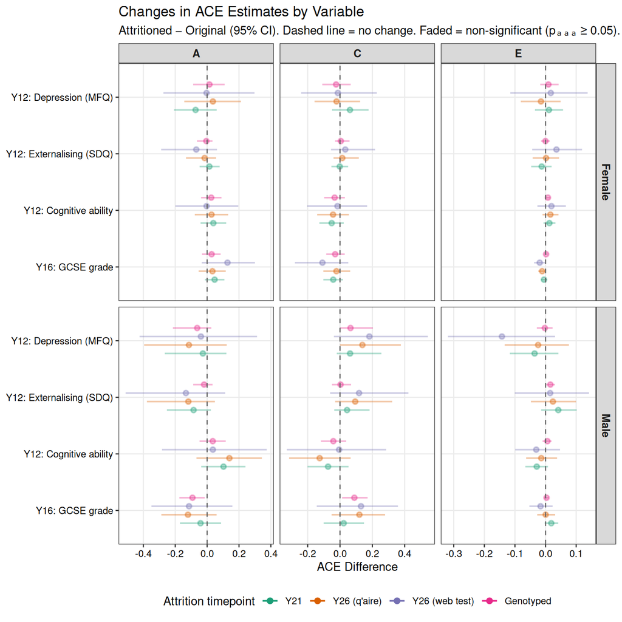

```r
ace_differences_tbl %>%
  mutate(
    par           = toupper(par),
    sex           = str_to_title(sex),
    name_clean    = rq6y_labels[match(name, rq6y)],
    name_clean    = factor(name_clean, levels = rev(rq6y_labels)),
    dataset_label = factor(
      rq1y_twin_labels_clean_extrashort[match(dataset, rq1y_twin1)],
      levels = rq1y_twin_labels_clean_extrashort[range_participation_outcomes]
    ),
    significant   = pval_adj < 0.05
  ) %>%
  ggplot(aes(
    x     = y,
    xmin  = ymin,
    xmax  = ymax,
    y     = name_clean,
    color = dataset_label,
    alpha = significant
  )) +
  geom_pointrange(position = position_dodge(width = 0.6), size = 0.4, linewidth = 0.7) +
  geom_vline(xintercept = 0, linetype = "dashed", color = "grey40", linewidth = 0.5) +
  facet_grid(sex ~ par, scales = "free_x") +
  scale_color_brewer(palette = "Dark2", name = "Attrition timepoint") +
  scale_alpha_manual(values = c("TRUE" = 1, "FALSE" = 0.35), guide = "none") +
  labs(
    title    = "Changes in ACE Estimates by Variable",
    subtitle = "Attritioned − Original (95% CI). Dashed line = no change. Faded = non-significant (p\u2090\u2090\u2090 \u2265 0.05).",
    x        = "ACE Difference",
    y        = NULL
  ) +
  theme_bw() +
  theme(
    strip.text      = element_text(face = "bold", size = 10),
    axis.text       = element_text(color = "black", size = 9),
    legend.position = "bottom",
    panel.grid.minor = element_blank()
  )
```

```r
save_plot("6_rq6_ace_forest", width = 7, height = 5)
```

View full-size plot

### ACE Estimates Plot

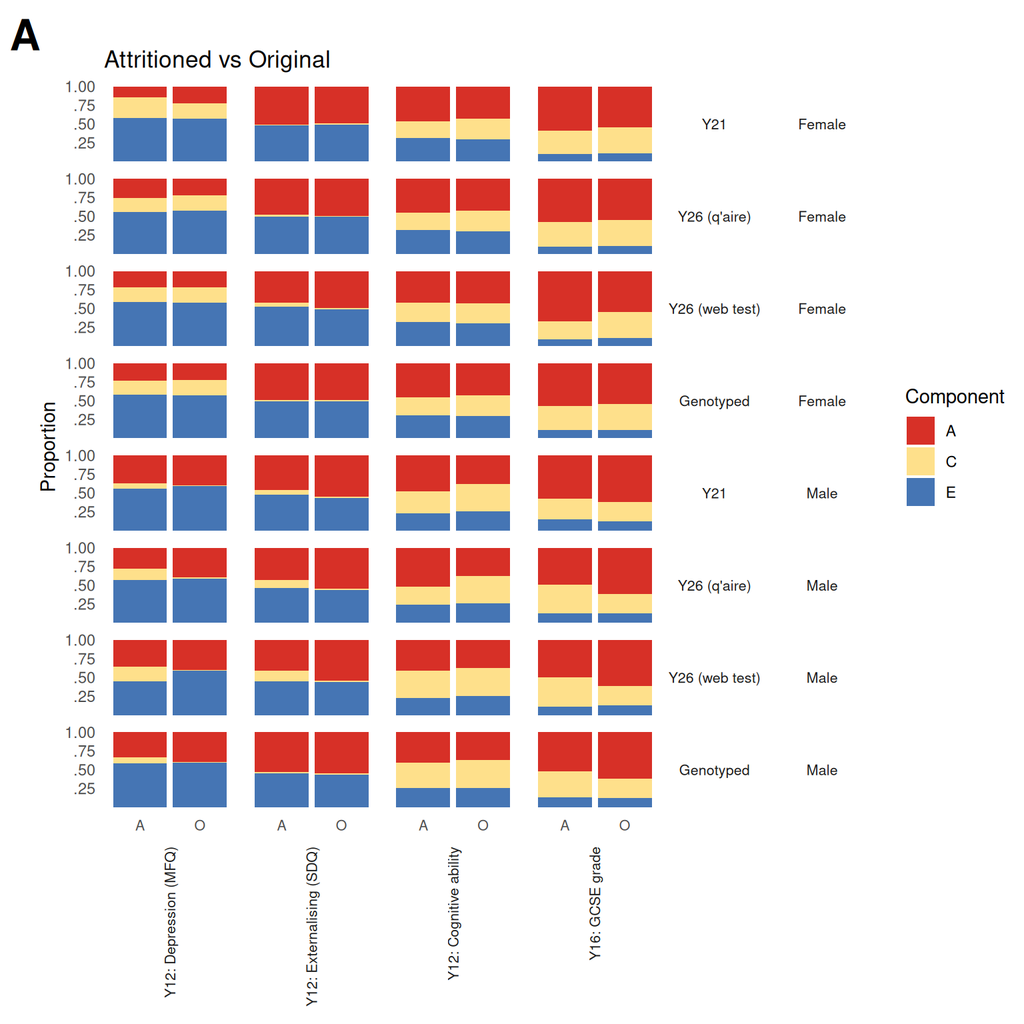

```r
ace_estimates %>%
  mutate(
    name_clean = rq6y_labels[match(name, rq6y)],
    name_clean = factor(name_clean, levels = rq6y_labels),
    group = ifelse(group == "df1", "A", "O"),
    group = factor(group, levels = c("A", "O")),
    sex = str_to_title(sex),
    par = toupper(par),
    dataset_label = factor(rq1y_twin_labels_clean_extrashort[match(dataset,rq1y_twin1)], levels = rq1y_twin_labels_clean_extrashort[range_participation_outcomes])
  ) %>%
  ggplot(aes(x = group, y = y, fill = par)) +
  geom_col(position = "stack", alpha = 1) +
  facet_grid(sex + dataset_label ~ name_clean, switch = "x") +
  theme_minimal() +
  theme(
    axis.text.x = element_text(angle = 0, hjust = .5, size = 8),
    strip.text = element_text(size = 8),
    strip.text.x = element_text(angle = 90, hjust = 1, vjust = .5),
    strip.text.y = element_text(angle = 0),
    strip.placement = "outside",
    panel.grid = element_blank(),
    plot.tag = element_text(hjust = 0, vjust = 0, size = 24, face = "bold"),
    plot.tag.position = "topleft"
  ) +
  labs(
    title = "Attritioned vs Original",
    x = NULL,
    y = "Proportion",
    fill = "Component",
    tag = "A"
  ) +
  scale_y_continuous(breaks = c(.25,.50,.75, 1), labels = c(".25",".50",".75","1.00")) +
  scale_fill_manual(values = c("A" = "#d73027", "C" = "#fee08b", "E" = "#4575b4")) +
  coord_cartesian(ylim = c(0, 1))
```

```r
save_plot("6_rq6_ace_comparison", width = 5, height = 8)
```

📊 View Full Resolution ACE Comparison Plot (PNG)

Although we see large-ish increases in the shared environment for depression symptoms in males, this is not significant even before multiple comparisons are corrected for.

## Effect of attritioning on sample sizes

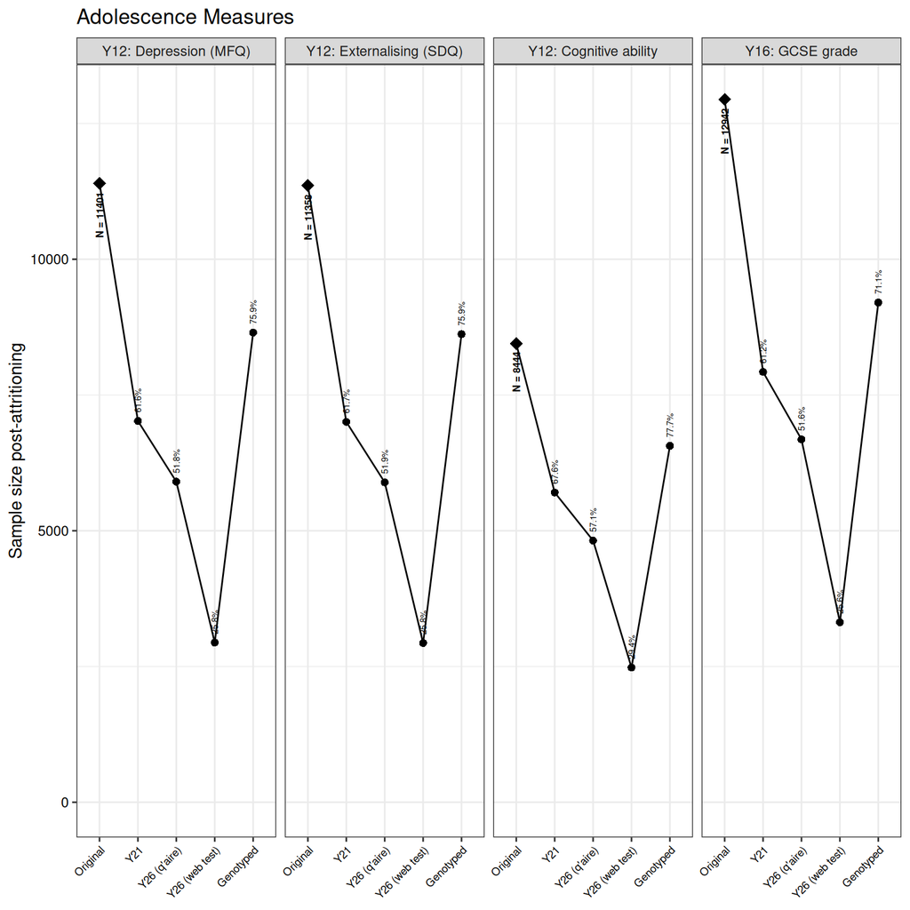

```r
response_statistics_rq6 = df %>%
  select(randomtwinid, all_of(rq6y), all_of(rq1y_twin1[range_participation_outcomes])) %>%
  mutate(all1 = 1) %>%
  pivot_longer(cols = all_of(rq6y), names_to = "variable", values_to = "score") %>%
  pivot_longer(cols = all_of(c("all1", rq1y_twin1[range_participation_outcomes])), names_to = "timepoint", values_to = "participation_indicator") %>%
  filter(!is.na(score)) %>%
  filter(participation_indicator == 1) %>%
  group_by(variable, timepoint) %>%
  summarise(
    n = dplyr::n(),
    .groups = "drop"
  ) %>%
  group_by(variable) %>%
  mutate(
    max     = base::max(n),
    percent = n / max
  )

response_statistics_rq6 %>%
  mutate(
    variable  = rq6y_labels[match(variable, rq6y)],
    variable  = factor(variable, levels = rq6y_labels),
    timepoint = rq1y_twin_labels_clean_extrashort[match(timepoint, rq1y_twin1)],
    timepoint = ifelse(is.na(timepoint), "Original", timepoint),
    timepoint = factor(timepoint, levels = c("Original", rq1y_twin_labels_clean_extrashort[range_participation_outcomes])),
    original  = factor(ifelse(timepoint == "Original", "Original", "Attritioned"))
  ) %>%
  ggplot(aes(x = timepoint, y = n, group = variable)) +
  geom_line() +
  geom_point(aes(shape = original, size = original)) +
  geom_text(
    data = ~ filter(.x, timepoint == "Original"),
    aes(label = paste0("N = ", as.character(n))),
    vjust = .5, hjust = 1.2, size = 2.2, angle = 90, fontface = "bold"
  ) +
  geom_text(
    data = ~ filter(.x, timepoint != "Original"),
    aes(label = paste0(round(percent * 100, digits = 1), "%")),
    vjust = .5, hjust = -.35, size = 1.9, angle = 90
  ) +
  scale_y_continuous(limits = c(0, NA)) +
  scale_shape_manual(values = c("Original" = 18, "Attritioned" = 16)) +
  scale_size_manual(values = c("Original" = 3.5, "Attritioned" = 2)) +
  labs(
    y     = "Sample size post-attritioning",
    x     = NULL,
    title = "Adolescence Measures"
  ) +
  facet_wrap(~variable, nrow = 1) +
  theme_bw() +
  theme(
    axis.text   = element_text(color = "black"),
    axis.text.x = element_text(angle = 45, vjust = 1, hjust = 1, size = 7),
    legend.position = "none"
  )
```

```r
save_plot("6_rq6_attrition_numbers", width = 7, height = 2.2)
```

📊 View Full Resolution Attrition Numbers Plot (PNG)

```r
ace_differences_tbl %>%
  filter(sex == "male" & name == "lcmfqt1") %>%
  select(-starts_with("."), -n, -pd) %>%
  mutate(name_clean = rq6y_labels[match(name, rq6y)]) %>%
  select(dataset_label, name_clean, par, sex, y, ymin, ymax, pval, pval_adj) %>%
  arrange(sex, dataset_label, name_clean, par) %>%
  mutate(par = toupper(par)) %>%
  gt(groupname_col = "sex") %>%
  fmt_number(decimals = 3) %>%
  tab_row_group(
    label = "Male",
    rows = sex == "male"
  ) %>%
  tab_row_group(
    label = "Female",
    rows = sex == "female"
  ) %>%
  cols_hide(sex) %>%
  cols_label(
    dataset_label = "Dataset",
    name_clean = "Variable",
    par = "",
    y = "Diff",
    ymin = "Lower",
    ymax = "Upper",
    pval = md("p<sub>unadj</sub>"),
    pval_adj = md("p<sub>adj</sub>")
  ) %>%
  tab_spanner(
    label = "95% CI",
    columns = c(ymin, ymax)
  ) %>%
  tab_style(
    style = cell_fill(color = "#d5e8d4"),
    locations = cells_body(
      columns = everything(),
      rows = pval_adj < 0.05 & y > 0
    )
  ) %>%
  tab_style(
    style = cell_fill(color = "#f8cecc"),
    locations = cells_body(
      columns = everything(),
      rows = pval_adj < 0.05 & y < 0
    )
  ) %>%
  tab_footnote(
    footnote = "Difference = Attritioned − Original. Adjusted P values are Bonferroni-Holm corrected within each sex, dataset, and parameter (A, C or E) group",
    locations = cells_column_labels(columns = pval_adj)
  ) %>%
  tab_options(
    table.font.size = px(9)
  )
```

| Dataset | Variable |  | Diff | 95% CI Lower | 95% CI Upper | p<sub>unadj</sub> | p<sub>adj</sub><sup>1</sup> |  |  |
| --- | --- | --- | --- | --- | --- | --- | --- | --- | --- |
| Male |  |  |  |  |  |  |  |  |  |
| Genotyped | Y12: Depression (MFQ) | A | −0.062 | −0.215 | 0.026 |  |  | 0.478 | 1.000 |
| Genotyped | Y12: Depression (MFQ) | C | 0.065 | 0.000 | 0.203 | 0.283 | 1.000 |  |  |
| Genotyped | Y12: Depression (MFQ) | E | −0.002 | −0.028 | 0.023 | 0.860 | 1.000 |  |  |
| Y21 (TEDS21 phase-1 questionnaire) | Y12: Depression (MFQ) | A | −0.026 | −0.266 | 0.121 | 0.985 | 1.000 |  |  |
| Y21 (TEDS21 phase-1 questionnaire) | Y12: Depression (MFQ) | C | 0.062 | −0.020 | 0.256 | 0.502 | 1.000 |  |  |
| Y21 (TEDS21 phase-1 questionnaire) | Y12: Depression (MFQ) | E | −0.036 | −0.117 | 0.042 | 0.374 | 1.000 |  |  |
| Y26 (CATSLife web tests) | Y12: Depression (MFQ) | A | −0.039 | −0.424 | 0.313 | 0.985 | 1.000 |  |  |
| Y26 (CATSLife web tests) | Y12: Depression (MFQ) | C | 0.181 | −0.038 | 0.543 | 0.410 | 1.000 |  |  |
| Y26 (CATSLife web tests) | Y12: Depression (MFQ) | E | −0.143 | −0.319 | 0.031 | 0.122 | 1.000 |  |  |
| Y26 (TEDS26 questionnaire) | Y12: Depression (MFQ) | A | −0.114 | −0.395 | 0.123 | 0.532 | 1.000 |  |  |
| Y26 (TEDS26 questionnaire) | Y12: Depression (MFQ) | C | 0.138 | 0.000 | 0.376 | 0.240 | 1.000 |  |  |
| Y26 (TEDS26 questionnaire) | Y12: Depression (MFQ) | E | −0.024 | −0.134 | 0.076 | 0.664 | 1.000 |  |  |

<sup>1</sup> Difference = Attritioned − Original. Adjusted P values are Bonferroni-Holm corrected within each sex, dataset, and parameter (A, C or E) group